# Tactile navigation

Jeppe

2023-05-01

## Introduction

A study on driving performance and In Vehicle infotainment system has been done. The study aims to answer two questions. 1) Can the addition of tactile navigation improve driving performance 2) Which tactile navigation (if any) improves driving performance most

The first part of this statistical analysis aims to investigate the sample to answer if the data is normally distributed and if the participants’s characteristics are distributed across the four conditions. If this is not the case an effect of condition could be attributed to other personal factors of the participants (e.g. gaming experience).

Dependent variables:  
- SUS  
- SART  
- Total Crash  
- Lane Breaks  
- Total Glances  
- Total Glance Time

Independent variable:  
- Condition (Acrylic, Bar, Combination & Touch only)

Demographics:  
- Age  
- Gender  
- Gaming  
- Drivers licence Years  
- Automatic gear experience  
- Car Simulator

## Population

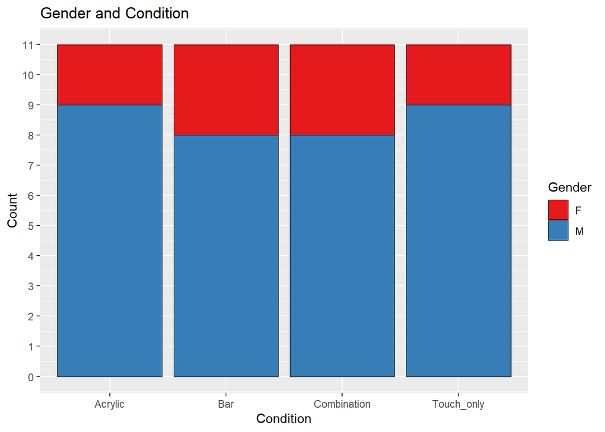

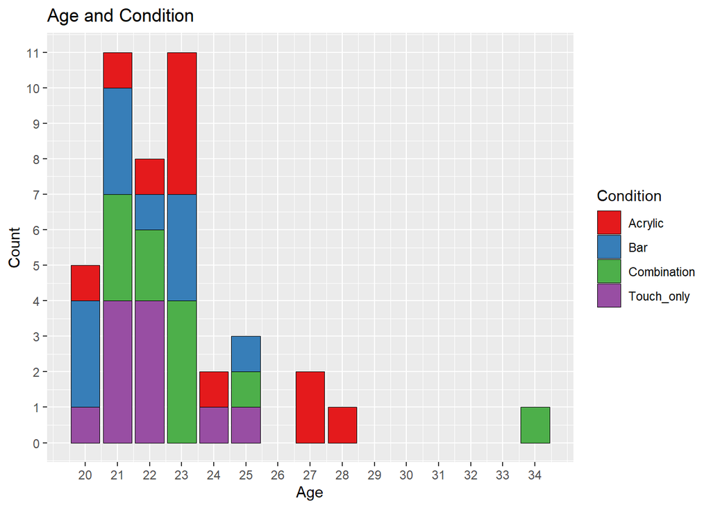

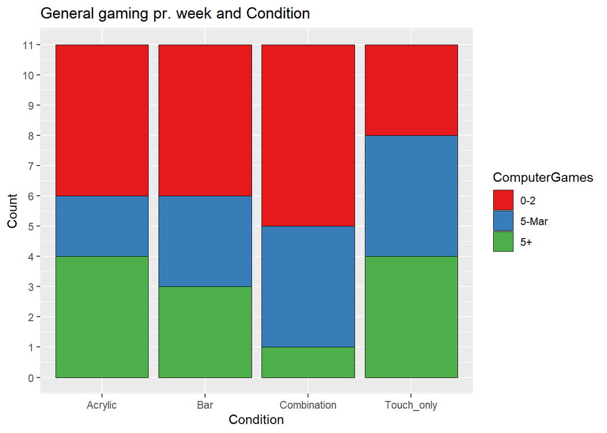

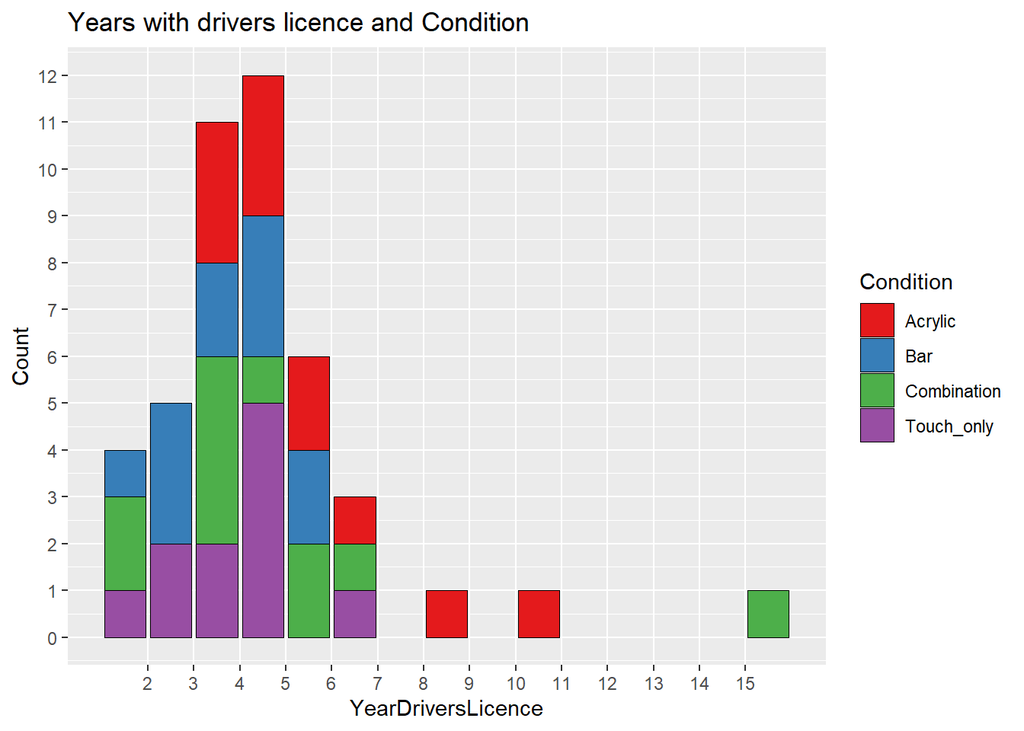

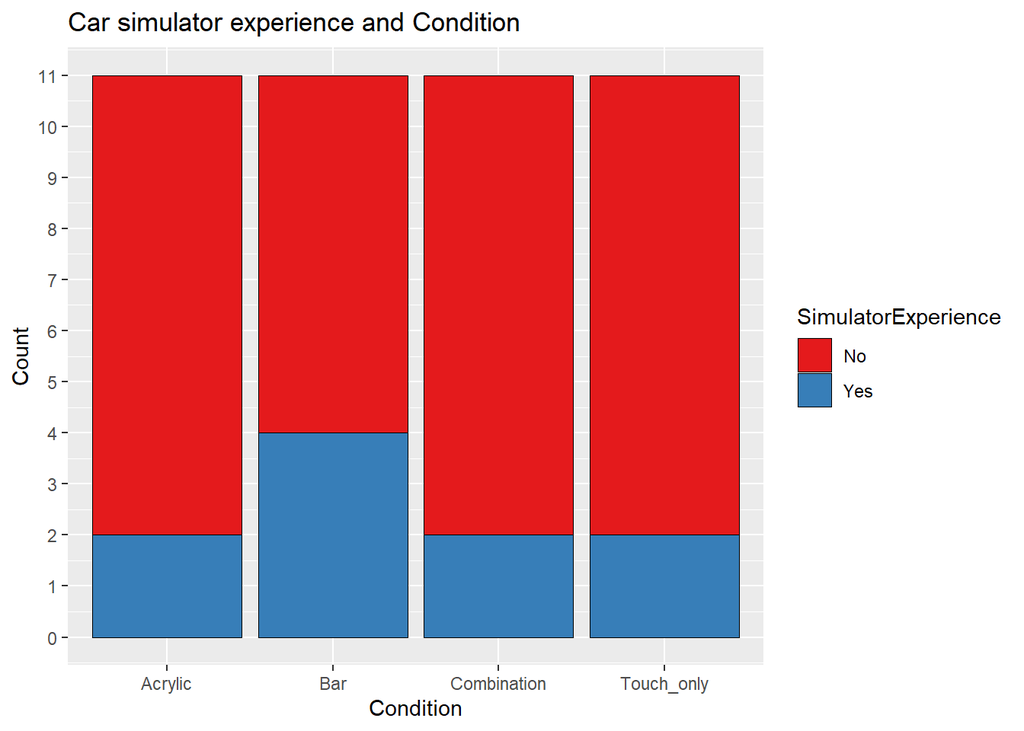

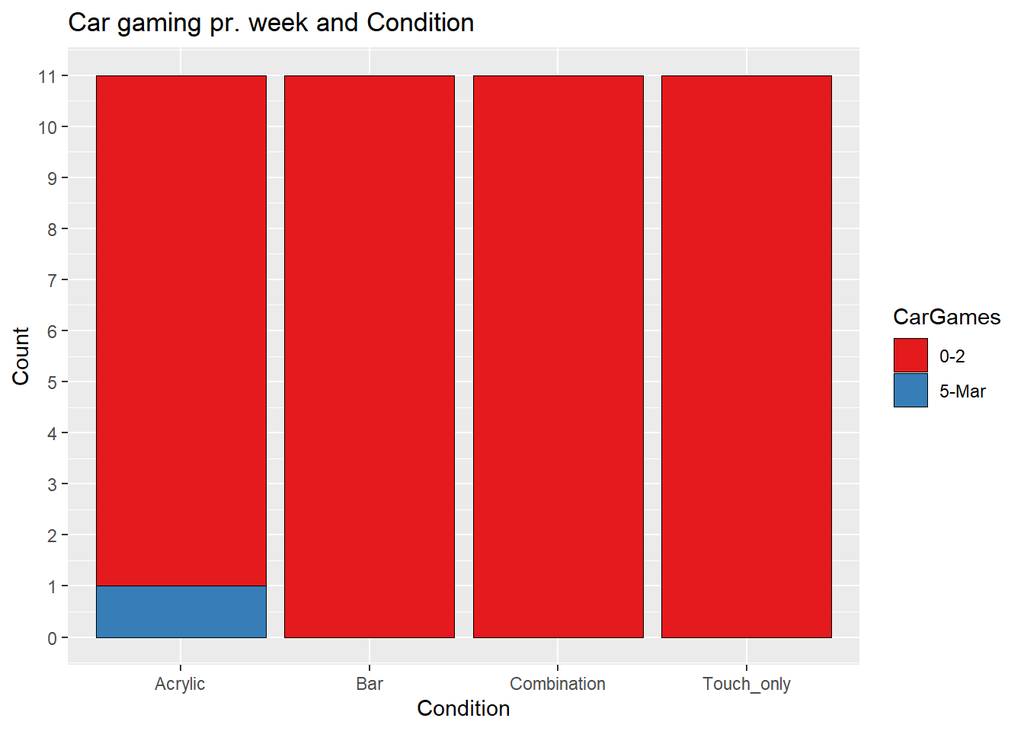

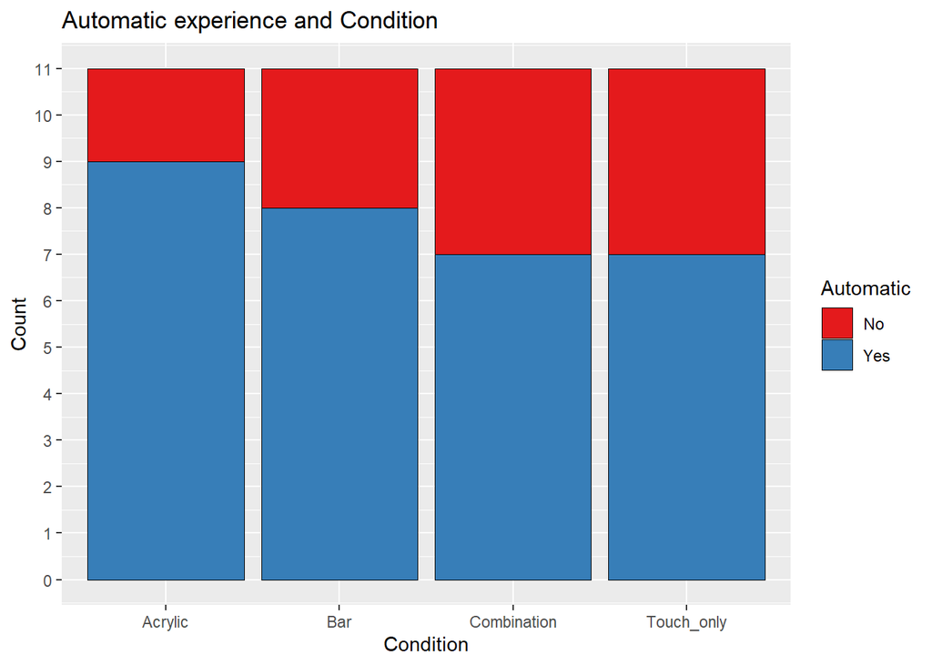

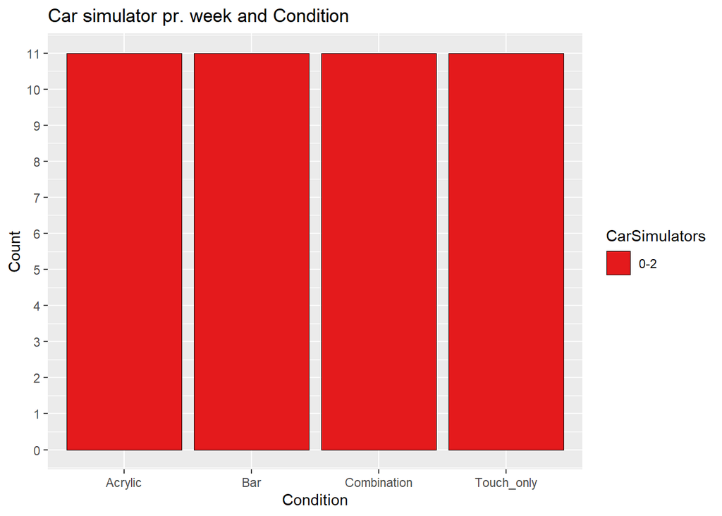

A summary of ‘Age’ and ‘Years with drivers licence’. As with the bar graph for age we have a lot of people between 20-23 and most participants have had a drivers licence for 3-5 years.

```r
Agessummary <- summary(dataFrame[c("Age")])

Drivingsummary <- summary(dataFrame[c("YearDriversLicence")])

Metricsummary <- summary(dataFrame[c("SART", "SUS", "TotalGlanceTime", "TotalGlances", "TotalCrash", "LaneBreaks")])

Agessummary
```

```
##       Age
##  Min.   :20.0
##  1st Qu.:21.0
##  Median :22.0
##  Mean   :22.7
##  3rd Qu.:23.0
##  Max.   :34.0
```

```r
sd(dataFrame$Age)
```

```
## [1] 2.575191
```

```r
Drivingsummary
```

```
##  YearDriversLicence
##  Min.   : 1.833
##  1st Qu.: 3.417
##  Median : 4.417
##  Mean   : 4.756
##  3rd Qu.: 5.417
##  Max.   :16.000
```

```r
sd(dataFrame$YearDriversLicence)
```

```
## [1] 2.426197
```

## Effect due to condition

To answer the first question of whether condition have an effect on the 6 metrics we’ll create a plot of means with confidence (95%) as whiskers. According to Geoff Cumming and Sue Finch if the data has the same standard deviation it is possible to gain insight into which data could be significantly different.

```r
plot1 <- plot1 + theme(legend.position = "none")
plot2 <- plot2 + theme(legend.position = "none")
plot3 <- plot3 + theme(legend.position = "none")
plot4 <- plot4 + theme(legend.position = "none")
plot5 <- plot5 + theme(legend.position = "none")
plot6 <- plot6 + theme(legend.position = "none")
```

### Distribution of metrics (Bar and density)

- SUS
- SART
- Total Crash
- Lane Breaks
- Total Glances
- Total Glance Time

#### Bar Charts

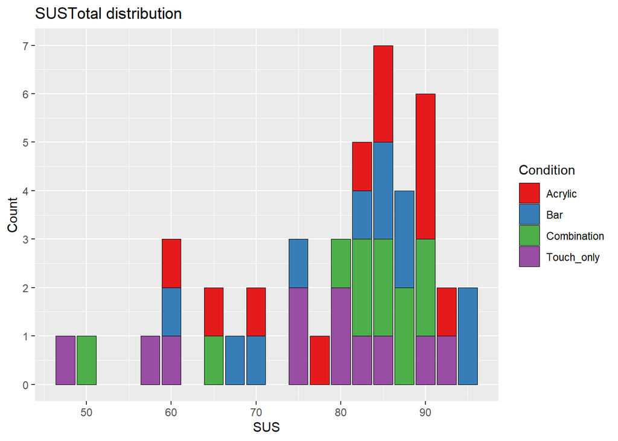

```r
SUSTotal <- ggplot(data = dataFrame, mapping = aes(x = SUS, fill = Condition))
SUSTotal <- SUSTotal + geom_bar(col = "black", size = .3) + scale_y_continuous(name = "Count", breaks = c(0:150)) + ggtitle("SUSTotal distribution") + scale_fill_brewer(palette = Palette)

SARTTotal <- ggplot(data = dataFrame, mapping = aes(x = SART, fill = Condition))
SARTTotal <- SARTTotal + geom_bar(col = "black", size = .3) + scale_y_continuous(name = "Count", breaks = c(0:150)) + ggtitle("SARTTotal distribution") + scale_fill_brewer(palette = Palette)

TotalCrashTotal <- ggplot(data = dataFrame, mapping = aes(x = TotalCrash, fill = Condition))
TotalCrashTotal <- TotalCrashTotal + geom_bar(col = "black", size = .3) + scale_y_continuous(name = "Count", breaks = c(0:150)) + ggtitle("TotalCrashTotal distribution") + scale_fill_brewer(palette = Palette)

LaneBreakTotal <- ggplot(data = dataFrame, mapping = aes(x = LaneBreaks, fill = Condition))
LaneBreakTotal <- LaneBreakTotal + geom_bar(col = "black", size = .3) + scale_y_continuous(name = "Count", breaks = c(0:150)) + ggtitle("LaneBreakTotal distribution") + scale_fill_brewer(palette = Palette)

GlancesTotal <- ggplot(data = dataFrame, mapping = aes(x = TotalGlances, fill = Condition))
GlancesTotal <- GlancesTotal + geom_bar(col = "black", size = .3) + scale_y_continuous(name = "Count", breaks = c(0:150)) + ggtitle("GlancesTotal distribution") + scale_fill_brewer(palette = Palette)

GlanceTimeTotal <- ggplot(data = dataFrame, mapping = aes(x = TotalGlanceTime, fill = Condition))
GlanceTimeTotal <- GlanceTimeTotal + geom_bar(col = "black", size = .3) + scale_y_continuous(name = "Count", breaks = c(0:150)) + ggtitle("SUGlanceTimeTotalSTotal distribution") + scale_fill_brewer(palette = Palette)

SUSTotal
```

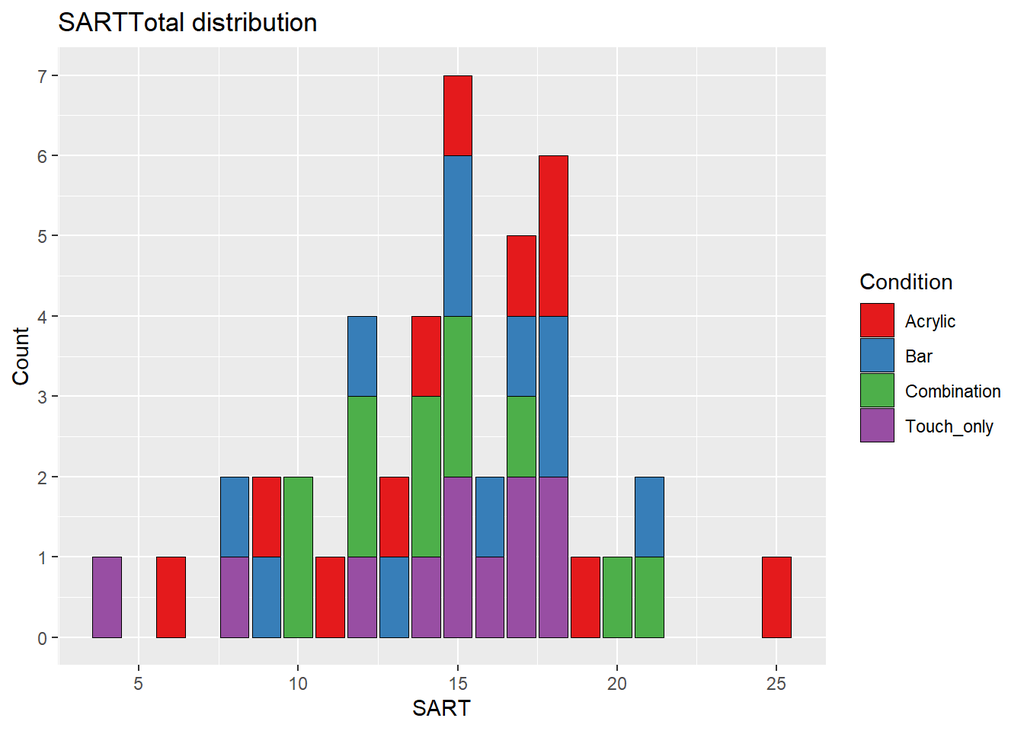

```r
SARTTotal
```

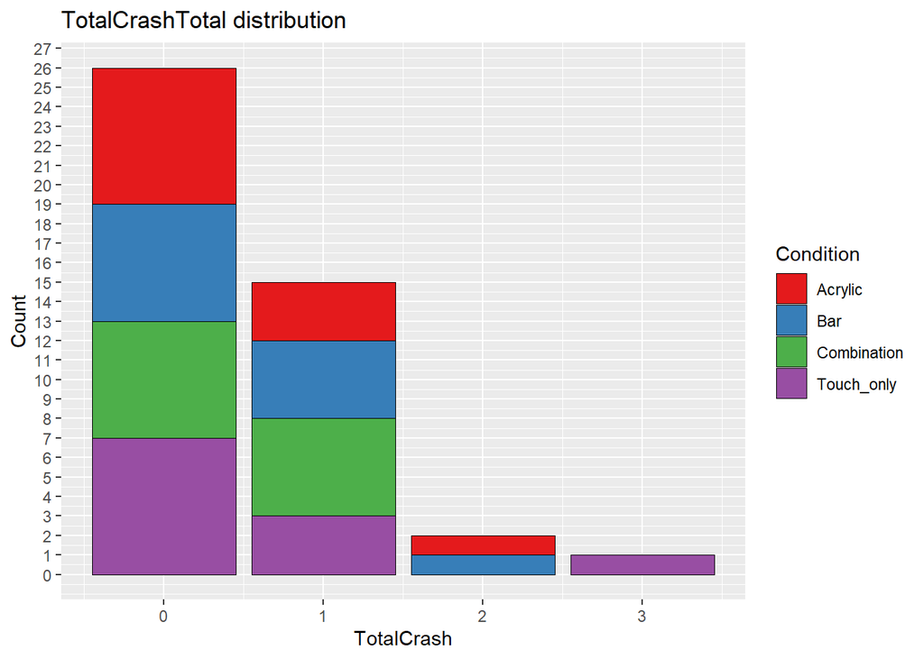

```r
TotalCrashTotal
```

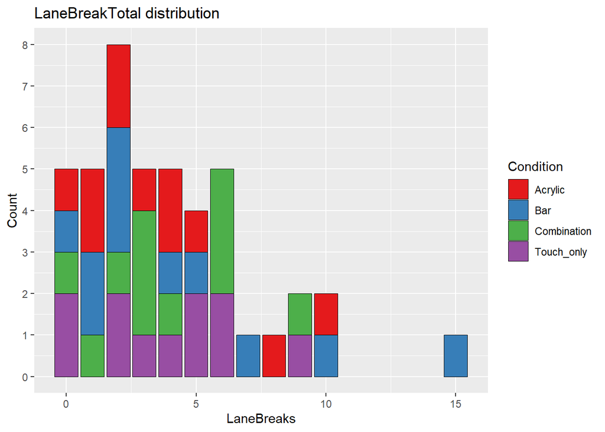

```r
LaneBreakTotal
```

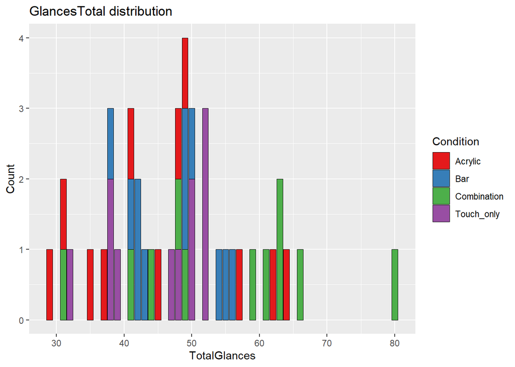

```r
GlancesTotal
```

[figure not shown]

```r
GlanceTimeTotal
```

#### Density

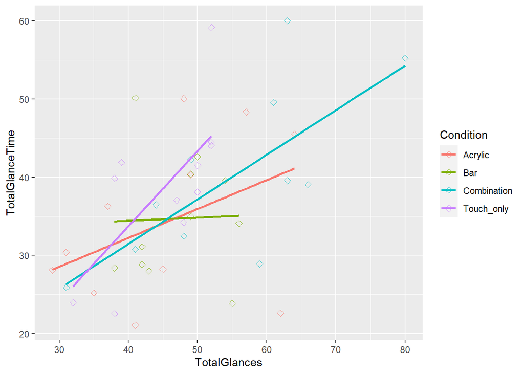

```r
alpha <- 0.4
SUSTotal <- ggplot(data = dataFrame, mapping = aes(x = SUS, fill = Condition, alpha = alpha))
SUSTotal <- SUSTotal + geom_density() + ggtitle("SUSTotal distribution") + scale_fill_brewer(palette = Palette)

SARTTotal <- ggplot(data = dataFrame, mapping = aes(x = SART, fill = Condition, alpha = alpha))
SARTTotal <- SARTTotal + geom_density() + ggtitle("SARTTotal distribution") + scale_fill_brewer(palette = Palette)

TotalCrashTotal <- ggplot(data = dataFrame, mapping = aes(x = TotalCrash, fill = Condition, alpha = alpha))
TotalCrashTotal <- TotalCrashTotal + geom_density() + ggtitle("TotalCrashTotal distribution") + scale_fill_brewer(palette = Palette)

LaneBreakTotal <- ggplot(data = dataFrame, mapping = aes(x = LaneBreaks, fill = Condition, alpha = alpha))
LaneBreakTotal <- LaneBreakTotal + geom_density() + ggtitle("LaneBreakTotal distribution") + scale_fill_brewer(palette = Palette)

GlancesTotal <- ggplot(data = dataFrame, mapping = aes(x = TotalGlances, fill = Condition, alpha = alpha))
GlancesTotal <- GlancesTotal + geom_density() + ggtitle("GlancesTotal distribution") + scale_fill_brewer(palette = Palette)

GlanceTimeTotal <- ggplot(data = dataFrame, mapping = aes(x = TotalGlanceTime, fill = Condition, alpha = alpha))
GlanceTimeTotal <- GlanceTimeTotal + geom_density() + ggtitle("SUGlanceTimeTotalSTotal distribution") + scale_fill_brewer(palette = Palette)

# SUSTotal
# SARTTotal
# TotalCrashTotal
# LaneBreakTotal
# GlancesTotal
# GlanceTimeTotal

ggplot(dataFrame, aes(x = TotalGlances, y = TotalGlanceTime, color = Condition)) +
    geom_point(size = 2, shape = 23) +
    geom_smooth(method = lm, se = FALSE)
```

## Statistical analysis

Statistics will be run on all driving performance metrics grouped by conditions, to look for significant main effects. The normality and the variance will be analysed to ensure the correct statistical test is being used. Sharpiro Wilk test will be used to analyse the distribution of the residuals. Bartlett’s test will be used in case of normality to analyse the variance Levenes test will be used in case the residuals are not normal distributed to analyse the variance

### Analysis of Glance Time grouped by conditions

The residuals proved to be normally distributed and the data has homogene variance which means a standard ANOVA test can be used

```r
glanceTimeData <- subset(dataFrame, select = c("Participants", "Condition", "TotalGlanceTime"))
summary(glanceTimeData)
```

```
##   Participants       Condition  TotalGlanceTime
##  P1     : 1    Acrylic    :11   Min.   :21.06
##  P10    : 1    Bar        :11   1st Qu.:28.71
##  P11    : 1    Combination:11   Median :36.77
##  P12    : 1    Touch_only :11   Mean   :36.93
##  P13    : 1                     3rd Qu.:42.32
##  P14    : 1                     Max.   :60.01
##  (Other):38
```

```r
get_summary_stats(glanceTimeData)
```

```
## # A tibble: 1 × 13
##   variable        n   min   max median    q1    q3   iqr   mad  mean    sd    se
##   <fct>       <dbl> <dbl> <dbl>  <dbl> <dbl> <dbl> <dbl> <dbl> <dbl> <dbl> <dbl>
## 1 TotalGlanc…    44  21.1  60.0   36.8  28.7  42.3  13.6  11.1  36.9  9.88  1.49
## # ℹ 1 more variable: ci <dbl>
```

```r
glanceTimeData %>%
    group_by(Condition) %>%
    identify_outliers(TotalGlanceTime)
```

```
## # A tibble: 3 × 5
##   Condition  Participants TotalGlanceTime is.outlier is.extreme
##   <fct>      <fct>                  <dbl> <lgl>      <lgl>
## 1 Touch_only P3                      59.2 TRUE       FALSE
## 2 Touch_only P4                      22.5 TRUE       FALSE
## 3 Touch_only P9                      24.0 TRUE       FALSE
```

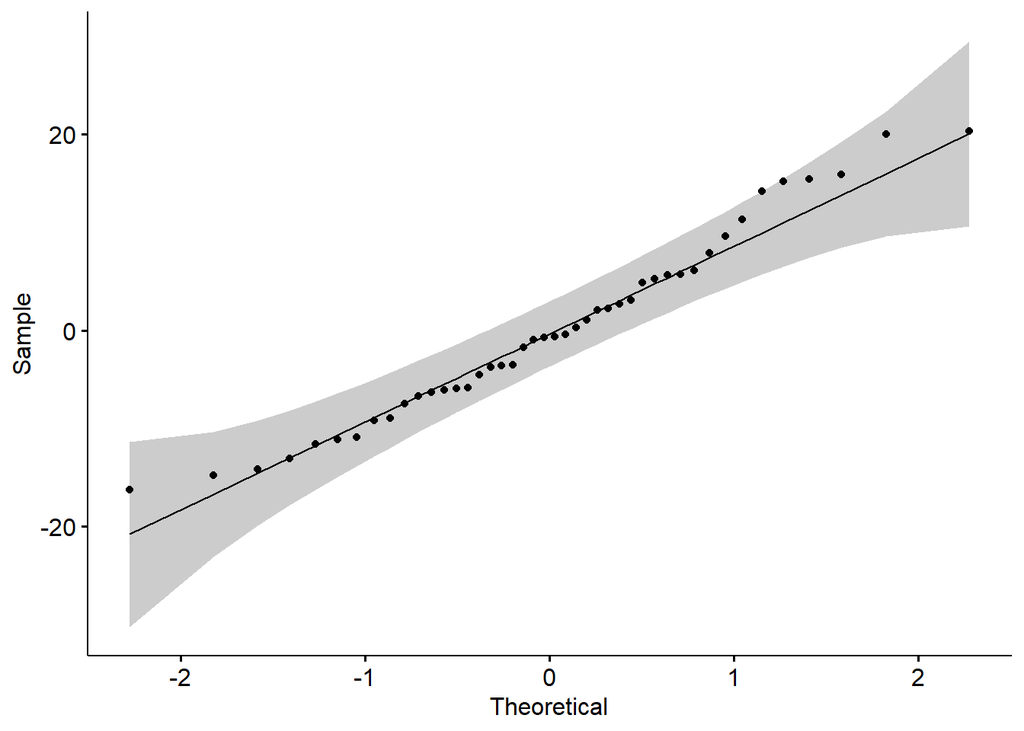

```r
glanceTimeModel <- lm(TotalGlanceTime ~ Condition, data = glanceTimeData)
ggqqplot(residuals(glanceTimeModel))
```

```r
shapiro_test(residuals(glanceTimeModel))
```

```
## # A tibble: 1 × 3
##   variable                   statistic p.value
##   <chr>                          <dbl>   <dbl>
## 1 residuals(glanceTimeModel)     0.970   0.302
```

```r
# We use a bartlett test as the residuals are normally distributed
bartlett.test(TotalGlanceTime ~ Condition, data = glanceTimeData)
```

```
##
##  Bartlett test of homogeneity of variances
##
## data:  TotalGlanceTime by Condition
## Bartlett's K-squared = 1.2274, df = 3, p-value = 0.7464
```

```r
glanceTimeTest <- glanceTimeData %>% anova_test(TotalGlanceTime ~ Condition)
glanceTimeTest
```

```
## ANOVA Table (type II tests)
##
##      Effect DFn DFd     F     p p<.05   ges
## 1 Condition   3  40 0.953 0.424       0.067
```

### Analysis of Glance Count grouped by conditions

```r
glanceCountData <- subset(dataFrame, select = c("Participants", "Condition", "TotalGlances"))
summary(glanceCountData)
```

```
##   Participants       Condition   TotalGlances
##  P1     : 1    Acrylic    :11   Min.   :29.00
##  P10    : 1    Bar        :11   1st Qu.:41.00
##  P11    : 1    Combination:11   Median :48.50
##  P12    : 1    Touch_only :11   Mean   :48.18
##  P13    : 1                     3rd Qu.:54.25
##  P14    : 1                     Max.   :80.00
##  (Other):38
```

```r
get_summary_stats(glanceCountData)
```

```
## # A tibble: 1 × 13
##   variable        n   min   max median    q1    q3   iqr   mad  mean    sd    se
##   <fct>       <dbl> <dbl> <dbl>  <dbl> <dbl> <dbl> <dbl> <dbl> <dbl> <dbl> <dbl>
## 1 TotalGlanc…    44    29    80   48.5    41  54.2  13.2  11.1  48.2  10.7  1.62
## # ℹ 1 more variable: ci <dbl>
```

```r
glanceCountData %>%
    group_by(Condition) %>%
    identify_outliers(TotalGlances)
```

```
## [1] Condition    Participants TotalGlances is.outlier   is.extreme
## <0 rows> (or 0-length row.names)
```

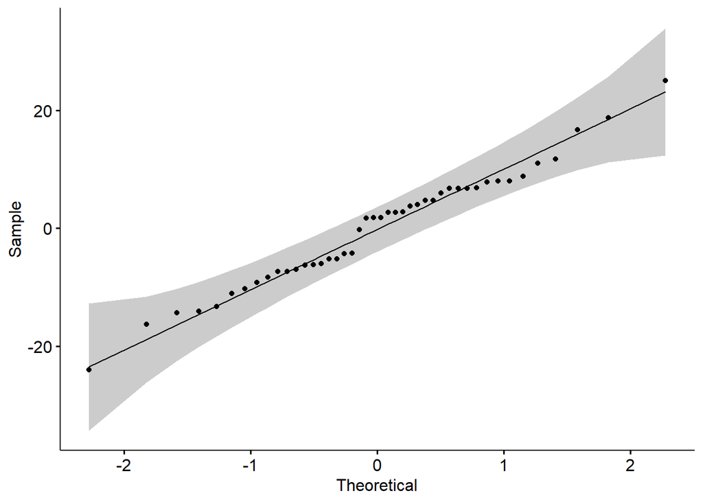

```r
glanceCountModel <- lm(TotalGlances ~ Condition, data = glanceCountData)
ggqqplot(residuals(glanceCountModel))
```

```r
shapiro_test(residuals(glanceCountModel))
```

```
## # A tibble: 1 × 3
##   variable                    statistic p.value
##   <chr>                           <dbl>   <dbl>
## 1 residuals(glanceCountModel)     0.982   0.730
```

```r
bartlett.test(TotalGlances ~ Condition, data = glanceCountData)
```

```
##
##  Bartlett test of homogeneity of variances
##
## data:  TotalGlances by Condition
## Bartlett's K-squared = 8.0415, df = 3, p-value = 0.04516
```

```r
glanceCountTest <- glanceCountData %>% welch_anova_test(TotalGlances ~ Condition)
glanceCountTest
```

```
## # A tibble: 1 × 7
##   .y.              n statistic   DFn   DFd     p method
## * <chr>        <int>     <dbl> <dbl> <dbl> <dbl> <chr>
## 1 TotalGlances    44      1.44     3  21.4  0.26 Welch ANOVA
```

### Analysis of Crash Count grouped by condition

```r
crashData <- subset(dataFrame, select = c("Participants", "Condition", "TotalCrash"))
summary(crashData)
```

```
##   Participants       Condition    TotalCrash
##  P1     : 1    Acrylic    :11   Min.   :0.0
##  P10    : 1    Bar        :11   1st Qu.:0.0
##  P11    : 1    Combination:11   Median :0.0
##  P12    : 1    Touch_only :11   Mean   :0.5
##  P13    : 1                     3rd Qu.:1.0
##  P14    : 1                     Max.   :3.0
##  (Other):38
```

```r
get_summary_stats(crashData)
```

```
## # A tibble: 1 × 13
##   variable       n   min   max median    q1    q3   iqr   mad  mean    sd    se
##   <fct>      <dbl> <dbl> <dbl>  <dbl> <dbl> <dbl> <dbl> <dbl> <dbl> <dbl> <dbl>
## 1 TotalCrash    44     0     3      0     0     1     1     0   0.5 0.699 0.105
## # ℹ 1 more variable: ci <dbl>
```

```r
crashData %>%
    group_by(Condition) %>%
    identify_outliers(TotalCrash)
```

```
## # A tibble: 1 × 5
##   Condition  Participants TotalCrash is.outlier is.extreme
##   <fct>      <fct>             <int> <lgl>      <lgl>
## 1 Touch_only P17                   3 TRUE       FALSE
```

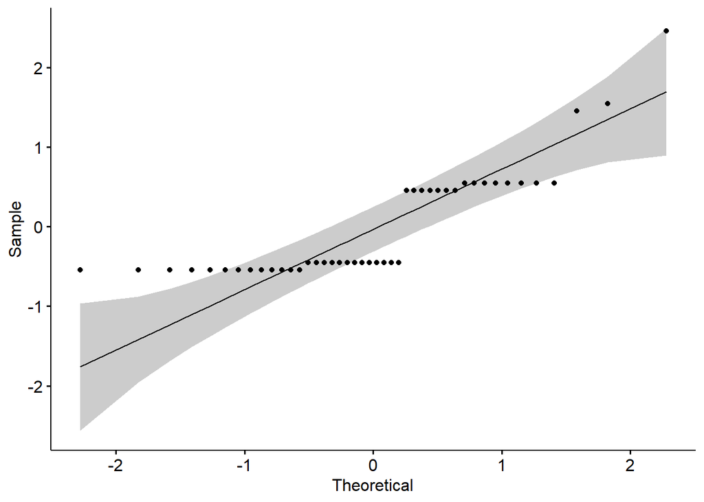

```r
crashDataModel <- lm(TotalCrash ~ Condition, data = crashData)
ggqqplot(residuals(crashDataModel))
```

```r
shapiro_test(residuals(crashDataModel))
```

```
## # A tibble: 1 × 3
##   variable                  statistic     p.value
##   <chr>                         <dbl>       <dbl>
## 1 residuals(crashDataModel)     0.740 0.000000182
```

```r
crashData %>% levene_test(TotalCrash ~ Condition)
```

```
## # A tibble: 1 × 4
##     df1   df2 statistic     p
##   <int> <int>     <dbl> <dbl>
## 1     3    40    0.0580 0.981
```

```r
crashDataTest <- crashData %>% kruskal_test(TotalCrash ~ Condition)
crashDataTest
```

```
## # A tibble: 1 × 6
##   .y.            n statistic    df     p method
## * <chr>      <int>     <dbl> <int> <dbl> <chr>
## 1 TotalCrash    44     0.203     3 0.977 Kruskal-Wallis
```

#### Crash Count visualization

Another way to present the crash data would be to score crashes pr condition:

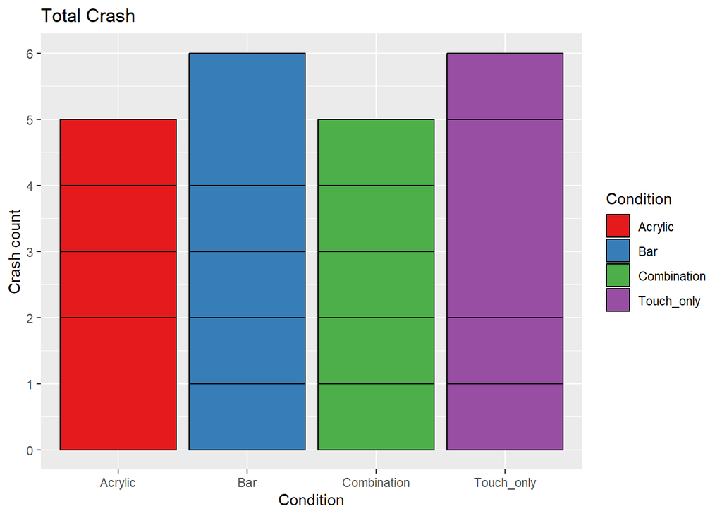

It can be seen on this graph that each condition has about the same total crashes and some conditions have one or two participants responsible for extra crashes.

### Analysis of Lane Breaks grouped by condition

```r
laneData <- subset(dataFrame, select = c("Participants", "Condition", "LaneBreaks"))
summary(laneData)
```

```
##   Participants       Condition    LaneBreaks
##  P1     : 1    Acrylic    :11   Min.   : 0.000
##  P10    : 1    Bar        :11   1st Qu.: 2.000
##  P11    : 1    Combination:11   Median : 3.000
##  P12    : 1    Touch_only :11   Mean   : 3.955
##  P13    : 1                     3rd Qu.: 6.000
##  P14    : 1                     Max.   :15.000
##  (Other):38
```

```r
get_summary_stats(laneData)
```

```
## # A tibble: 1 × 13
##   variable       n   min   max median    q1    q3   iqr   mad  mean    sd    se
##   <fct>      <dbl> <dbl> <dbl>  <dbl> <dbl> <dbl> <dbl> <dbl> <dbl> <dbl> <dbl>
## 1 LaneBreaks    44     0    15      3     2     6     4  2.96  3.96  3.25  0.49
## # ℹ 1 more variable: ci <dbl>
```

```r
laneData %>%
    group_by(Condition) %>%
    identify_outliers(LaneBreaks)
```

```
## # A tibble: 2 × 5
##   Condition Participants LaneBreaks is.outlier is.extreme
##   <fct>     <fct>             <int> <lgl>      <lgl>
## 1 Acrylic   P28                  10 TRUE       FALSE
## 2 Bar       P35                  15 TRUE       FALSE
```

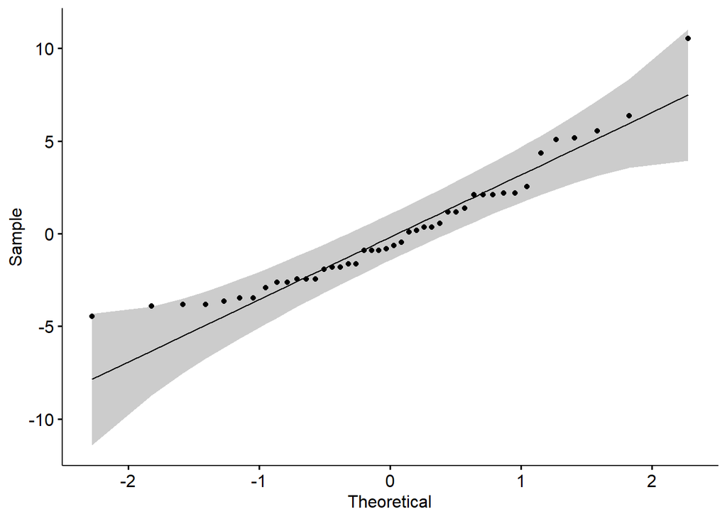

```r
laneDataModel <- lm(LaneBreaks ~ Condition, data = laneData)
ggqqplot(residuals(laneDataModel))
```

```r
shapiro_test(residuals(laneDataModel))
```

```
## # A tibble: 1 × 3
##   variable                 statistic p.value
##   <chr>                        <dbl>   <dbl>
## 1 residuals(laneDataModel)     0.923 0.00582
```

```r
laneData %>% levene_test(LaneBreaks ~ Condition)
```

```
## # A tibble: 1 × 4
##     df1   df2 statistic     p
##   <int> <int>     <dbl> <dbl>
## 1     3    40     0.461 0.711
```

```r
laneDataTest <- laneData %>% kruskal_test(LaneBreaks ~ Condition)
laneDataTest
```

```
## # A tibble: 1 × 6
##   .y.            n statistic    df     p method
## * <chr>      <int>     <dbl> <int> <dbl> <chr>
## 1 LaneBreaks    44     0.234     3 0.972 Kruskal-Wallis
```

### Analysis of SUS grouped by condition

```r
susData <- subset(dataFrame, select = c("Participants", "Condition", "SUS"))
summary(susData)
```

```
##   Participants       Condition       SUS
##  P1     : 1    Acrylic    :11   Min.   :47.50
##  P10    : 1    Bar        :11   1st Qu.:73.75
##  P11    : 1    Combination:11   Median :82.50
##  P12    : 1    Touch_only :11   Mean   :79.26
##  P13    : 1                     3rd Qu.:87.50
##  P14    : 1                     Max.   :95.00
##  (Other):38
```

```r
get_summary_stats(susData)
```

```
## # A tibble: 1 × 13
##   variable     n   min   max median    q1    q3   iqr   mad  mean    sd    se
##   <fct>    <dbl> <dbl> <dbl>  <dbl> <dbl> <dbl> <dbl> <dbl> <dbl> <dbl> <dbl>
## 1 SUS         44  47.5    95   82.5  73.8  87.5  13.8  11.1  79.3  12.1  1.83
## # ℹ 1 more variable: ci <dbl>
```

```r
susData %>%
    group_by(Condition) %>%
    identify_outliers(SUS)
```

```
## # A tibble: 2 × 5
##   Condition   Participants   SUS is.outlier is.extreme
##   <fct>       <fct>        <dbl> <lgl>      <lgl>
## 1 Combination P15             65 TRUE       FALSE
## 2 Combination P43             50 TRUE       TRUE
```

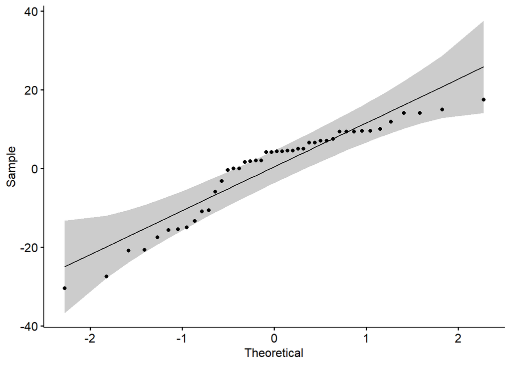

```r
susDataModel <- lm(SUS ~ Condition, data = susData)
ggqqplot(residuals(susDataModel))
```

```r
shapiro_test(residuals(susDataModel))
```

```
## # A tibble: 1 × 3
##   variable                statistic p.value
##   <chr>                       <dbl>   <dbl>
## 1 residuals(susDataModel)     0.901 0.00116
```

```r
susData %>% levene_test(SUS ~ Condition)
```

```
## # A tibble: 1 × 4
##     df1   df2 statistic     p
##   <int> <int>     <dbl> <dbl>
## 1     3    40     0.214 0.886
```

```r
susDataTest <- susData %>% kruskal_test(SUS ~ Condition)
susDataTest
```

```
## # A tibble: 1 × 6
##   .y.       n statistic    df     p method
## * <chr> <int>     <dbl> <int> <dbl> <chr>
## 1 SUS      44      1.97     3 0.578 Kruskal-Wallis
```

### Analysis of SART grouped by condition

```r
sartData <- subset(dataFrame, select = c("Participants", "Condition", "SART"))
sartData <- sartData[!(sartData$Participants == "P12" | sartData$Participants == "P13" | sartData$Participants == "P29" | sartData$Participants == "P30"), ]
summary(sartData)
```

```
##   Participants       Condition       SART
##  P1     : 1    Acrylic    :10   Min.   : 4.00
##  P10    : 1    Bar        :10   1st Qu.:12.00
##  P11    : 1    Combination:10   Median :15.00
##  P14    : 1    Touch_only :10   Mean   :14.32
##  P15    : 1                     3rd Qu.:17.00
##  P16    : 1                     Max.   :25.00
##  (Other):34
```

```r
get_summary_stats(sartData)
```

```
## # A tibble: 1 × 13
##   variable     n   min   max median    q1    q3   iqr   mad  mean    sd    se
##   <fct>    <dbl> <dbl> <dbl>  <dbl> <dbl> <dbl> <dbl> <dbl> <dbl> <dbl> <dbl>
## 1 SART        40     4    25     15    12    17     5  4.45  14.3  4.34 0.686
## # ℹ 1 more variable: ci <dbl>
```

```r
sartData %>%
    group_by(Condition) %>%
    identify_outliers(SART)
```

```
## # A tibble: 3 × 5
##   Condition   Participants  SART is.outlier is.extreme
##   <fct>       <fct>        <int> <lgl>      <lgl>
## 1 Combination P7              20 TRUE       FALSE
## 2 Combination P20             21 TRUE       FALSE
## 3 Touch_only  P17              4 TRUE       FALSE
```

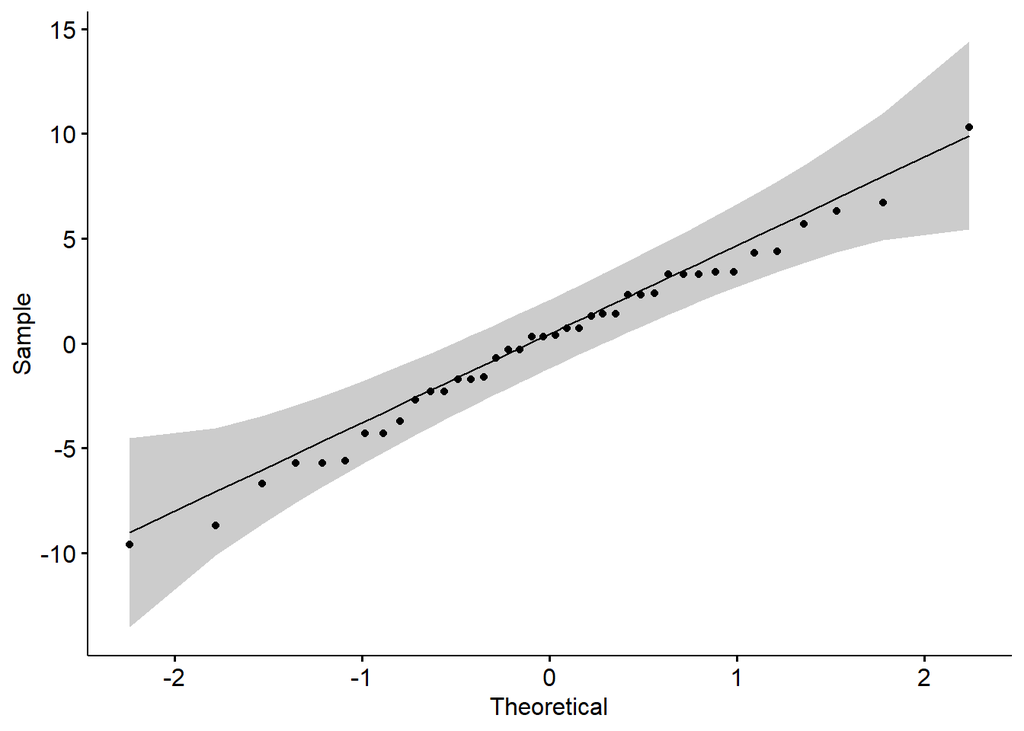

```r
sartDataModel <- lm(SART ~ Condition, data = sartData)
ggqqplot(residuals(sartDataModel))
```

```r
shapiro_test(residuals(sartDataModel))
```

```
## # A tibble: 1 × 3
##   variable                 statistic p.value
##   <chr>                        <dbl>   <dbl>
## 1 residuals(sartDataModel)     0.988   0.947
```

```r
bartlett.test(SART ~ Condition, data = sartData)
```

```
##
##  Bartlett test of homogeneity of variances
##
## data:  SART by Condition
## Bartlett's K-squared = 1.3196, df = 3, p-value = 0.7245
```

```r
sartDataTest <- sartData %>% anova_test(SART ~ Condition)
sartDataTest
```

```
## ANOVA Table (type II tests)
##
##      Effect DFn DFd     F    p p<.05   ges
## 1 Condition   3  36 0.133 0.94       0.011
```

### Analysis of use of aid grouped by condition

```r
aidData <- subset(dataFrame, select = c("Participants", "Condition", "UseOfAid"))
aidData <- aidData[!(aidData$Condition == "Touch_only"), ]
summary(aidData)
```

```
##   Participants       Condition     UseOfAid
##  P1     : 1    Acrylic    :11   Min.   :0.0000
##  P11    : 1    Bar        :11   1st Qu.:0.0000
##  P12    : 1    Combination:11   Median :0.0000
##  P14    : 1    Touch_only : 0   Mean   :0.8182
##  P15    : 1                     3rd Qu.:1.0000
##  P19    : 1                     Max.   :4.0000
##  (Other):27
```

```r
get_summary_stats(aidData)
```

```
## # A tibble: 1 × 13
##   variable     n   min   max median    q1    q3   iqr   mad  mean    sd    se
##   <fct>    <dbl> <dbl> <dbl>  <dbl> <dbl> <dbl> <dbl> <dbl> <dbl> <dbl> <dbl>
## 1 UseOfAid    33     0     4      0     0     1     1     0 0.818  1.33 0.232
## # ℹ 1 more variable: ci <dbl>
```

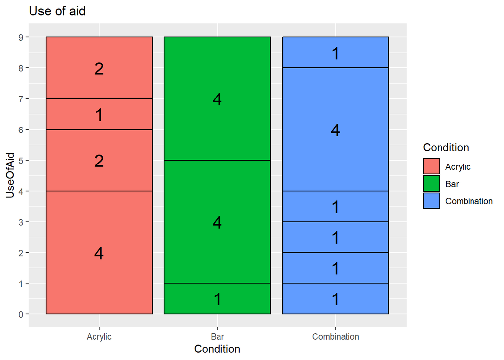

```r
aidPlotData <- subset(aidData, UseOfAid > 0)
aidPlot <- ggplot(data = aidPlotData, mapping = aes(x = Condition, y = UseOfAid, fill = Condition, label = UseOfAid))
aidPlot + geom_col(col = "black") +
    scale_y_continuous(name = "UseOfAid", breaks = c(0:15)) + ggtitle("Use of aid ") +
    geom_text(size = 6, position = position_stack(vjust = 0.5))
```

## Plot of means - All Dependent variables vs All Independent variables

To investigate weather differences in demographics have had an influence on conditions a plot of means for each metric will be performed with each independent variable. This will be done with wiskers as 95% confidence interval and if the data has homoscedasticity it could be possible to eyeball significant influences. If these are detected we’ll perform a t-test

Dependent variables:  
- SUS  
- SART  
- Total Crash  
- Lane Breaks  
- Total Glances  
- Total Glance Time

Independent variables:  
- Condition  
- Gender  
- Gaming  
- Drivers licence (This plot will have a linear model underneath it (x=Years with drivers license y=Dependent variable)) - Automatic gear  
- Car Simulator

### SUS

[figure not shown]

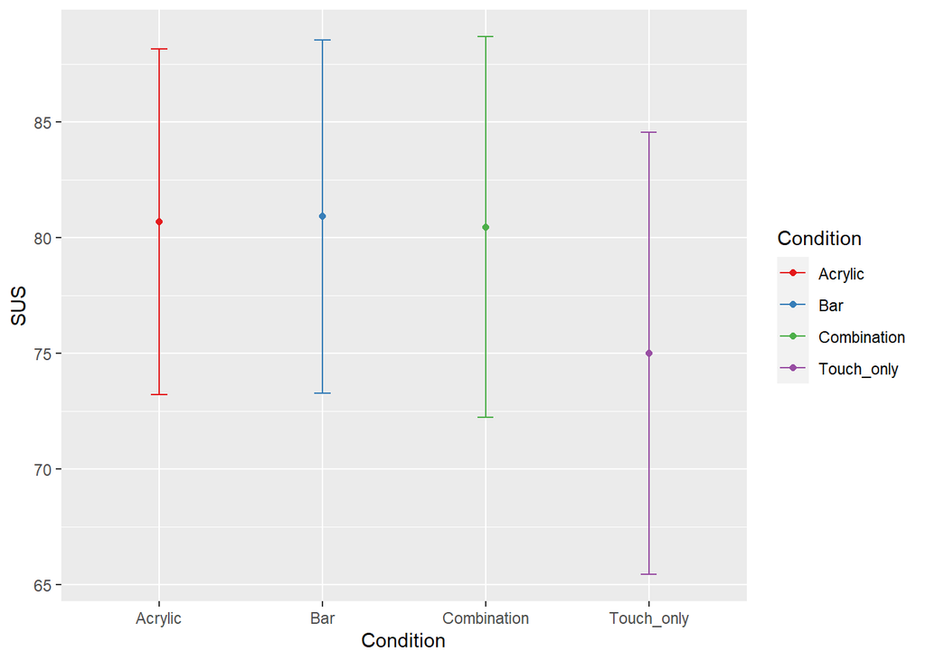

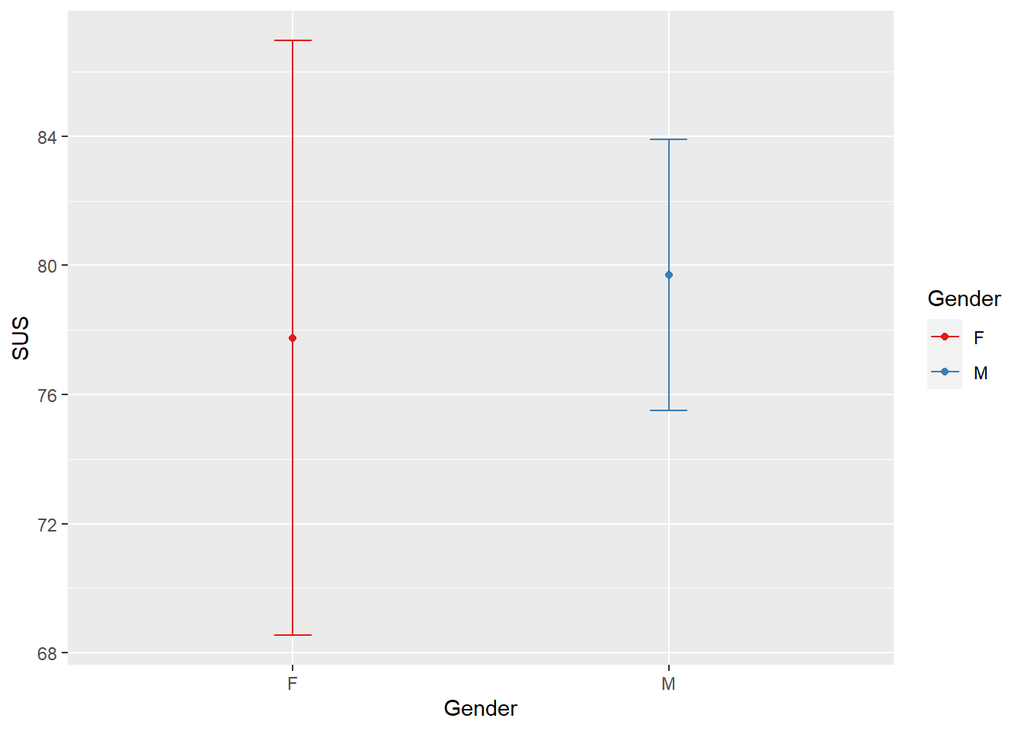

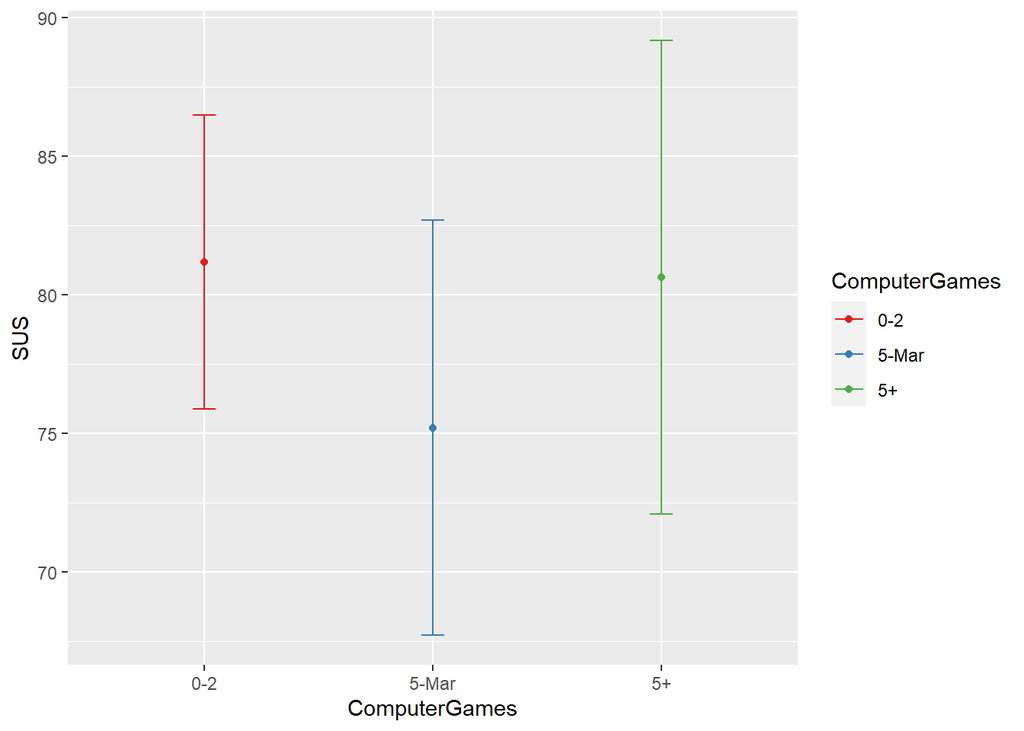

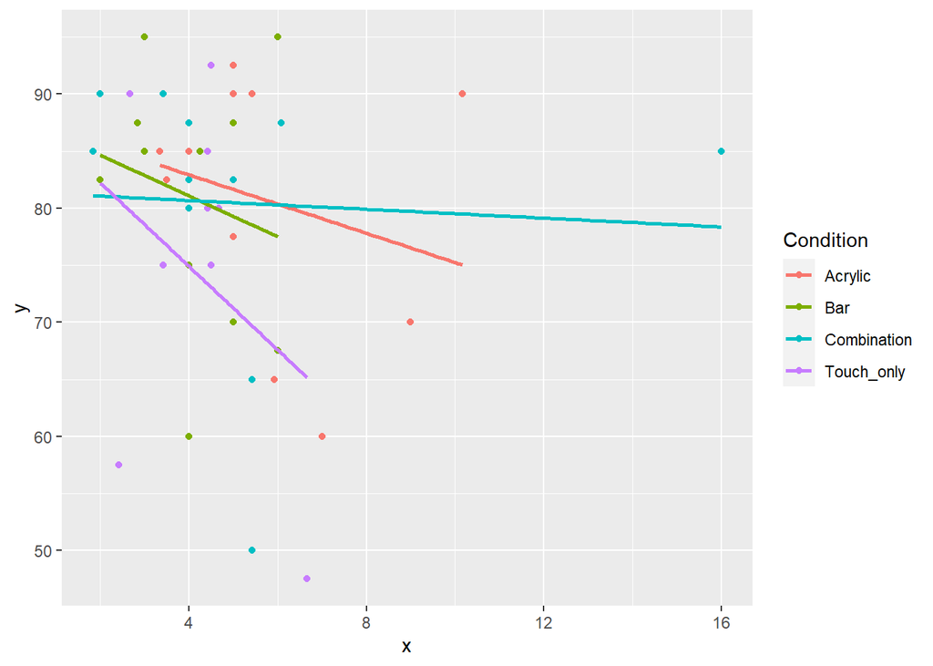

```
##
## [[5]]
##
## Call:
## lm(formula = y ~ x, data = dataFrame)
##
## Residuals:
##     Min      1Q  Median      3Q     Max
## -30.736  -5.481   3.101   9.028  16.407
##
## Coefficients:
##             Estimate Std. Error t value Pr(>|t|)
## (Intercept)  81.8139     4.0829   20.04   <2e-16 ***
## x            -0.5367     0.7666   -0.70    0.488
## ---
## Signif. codes:  0 '***' 0.001 '**' 0.01 '*' 0.05 '.' 0.1 ' ' 1
##
## Residual standard error: 12.2 on 42 degrees of freedom
## Multiple R-squared:  0.01154,    Adjusted R-squared:  -0.012
## F-statistic: 0.4903 on 1 and 42 DF,  p-value: 0.4877
##
##
## [[6]]
```

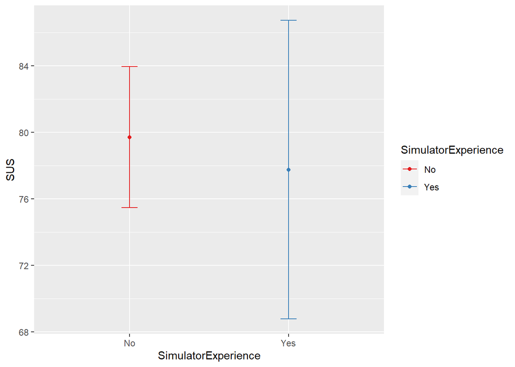

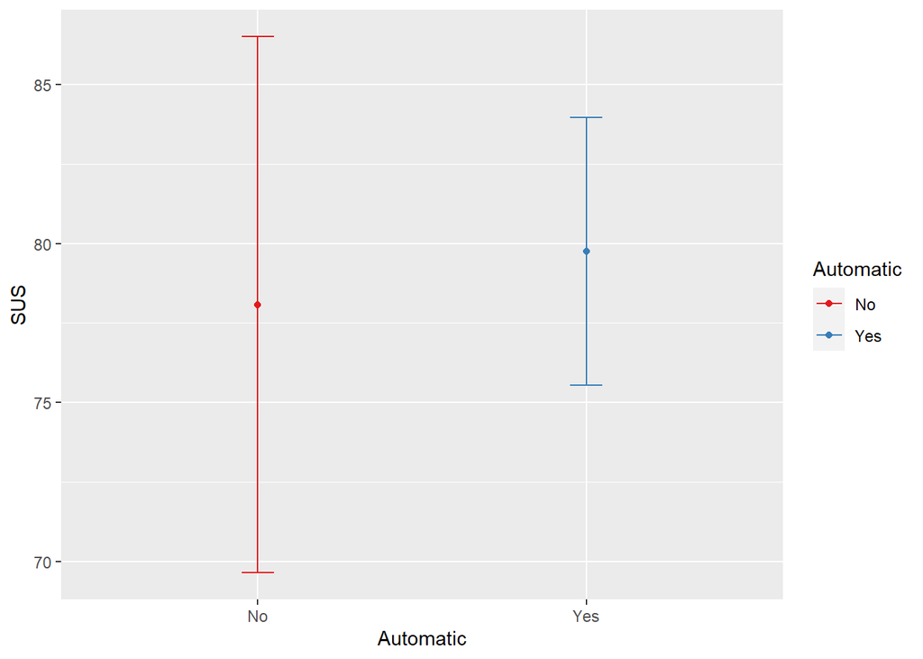

```r
SaveSixPlots(Metric = "SUS")
```